# Open Science: Extension Exercises

Ben Whalley

September 2020

# Zenodo

Go to the Zenodo.org website. Find examples of data analysis supplements for psychological papers which have been shared as Rmarkdown.

If you have trouble finding one, this is a recent example which includes only plots: https://zenodo.org/record/3560306#.X37EXy2ZOCM

This is another which includes both plots and some linear models: https://zenodo.org/record/3897511#.X37EVy2ZOCM

Try and find a few figures or statistics reported in the journal articles these files support. Can you follow enough of the Rmd to work our where they are calculated? (You might not understand *all* the R code, but this should still be possible).

# Reproduce a plot

Sioros et al. (2014) present findings from a repeat measures study on syncopation in music. Based on experiment A, the authors present these plots:

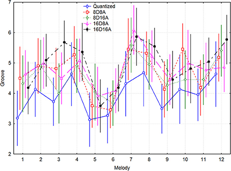

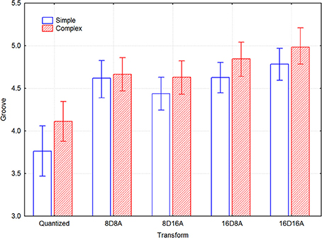

These files share the data from the experiments: https://zenodo.org/record/1221315#.X37O1C2ZOCM

Try to recreate one or both of the plots, using ggplot. Try to improve them if you can, based on Tufte’s principles of graphical excellence (see week 11 session on visualisation).

- You will need to use both an x-axis AND a facet to create the pairs of columns shown in the original plot.
- For bar charts, `color=VAR` will only change the outline color of the bar. Use `fill=VAR` instead.
- Without pre-processing the data to change category labels and variable names it will be hard to get the plot to match exactly.
- You may also find it difficult to get the categories in the same order as the original plot. You can use the `fct_rev(VARABLENAME)` function to reverse the order of factor variables, or look at the help files for `fct_reorder()`.

In it’s simplest form, without any tidying up of labels or formatting and using ggplot defaults, the plot might look something like this:

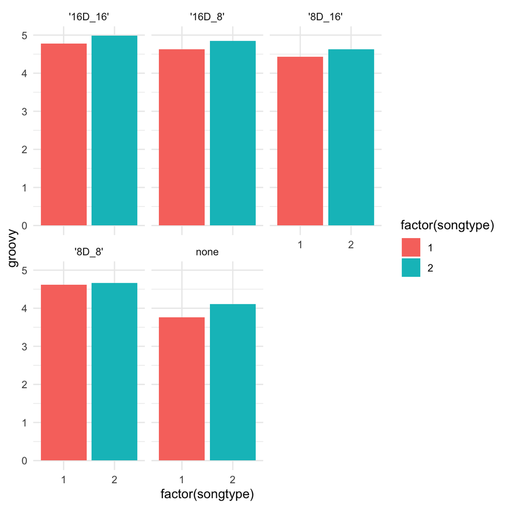

You can add error bars using `stat_summary(geom="errorbar")`, and change the number of columns to aid readability.

But perhaps try something a bit more data-rich, and which shows the true variability in the data?

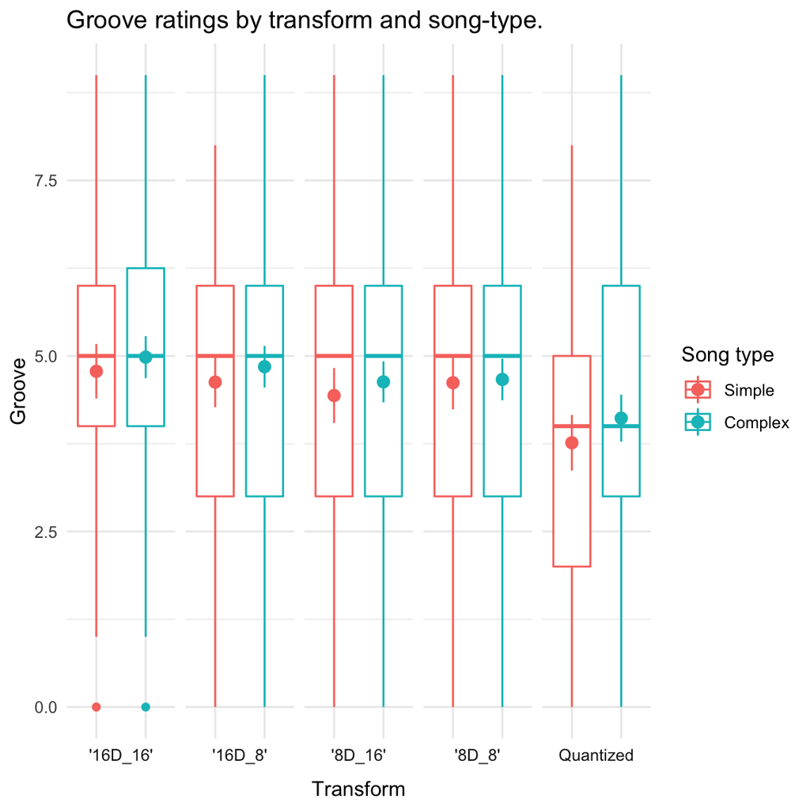

```
> $colour
> [1] FALSE
>
> attr(,"class")
> [1] "guides"
```

Does the result look as clear/convincing when we plot it this way?

Sioros, George, Marius Miron, Matthew Davies, Fabien Gouyon, and Guy Madison. 2014. “Syncopation Creates the Sensation of Groove in Synthesized Music Examples.” *Frontiers in Psychology* 5: 1036. https://www.frontiersin.org/articles/10.3389/fpsyg.2014.01036/full#h3.

Return to the index page

All content on this site distributed under a [Creative Commons](https://creativecommons.org/) licence. CC-BY-SA 4.0.